# Product Pricing and Purchase Behavior

### Pounds

Analyzing the products measured in pounds will be similar to analyzing products measured by count. Let’s look at the overall histogram.

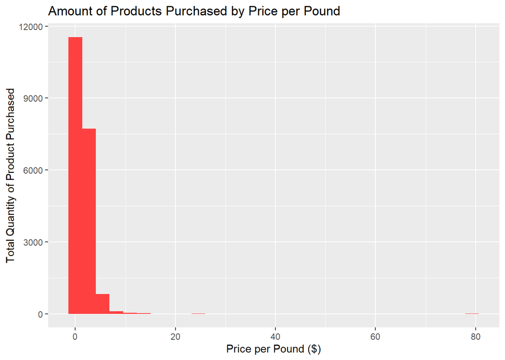

```r
create_unit_histogram(products_lb, unit = lb, color = "brown1") +
  labs(title = "Amount of Products Purchased by Price per Pound",
       x  = "Price per Pound ($)",
       y = "Total Quantity of Product Purchased"
       )
```

Looking at this distribution, there are very clearly some extreme outliers in this dataset. Let’s make another boxplot.

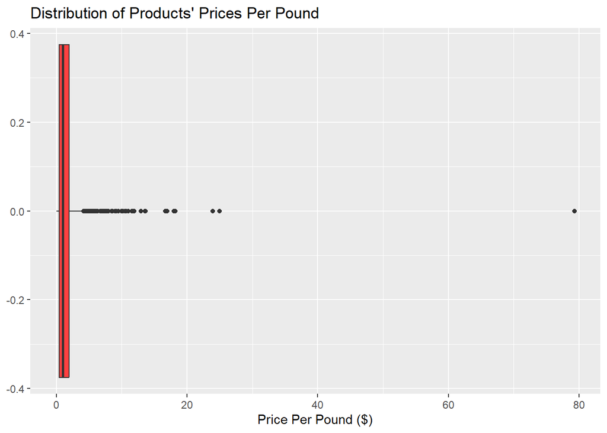

```r
create_unit_boxplot(products_lb, color = "brown1") +
  labs(title = "Distribution of Products' Prices Per Pound",
       x = "Price Per Pound ($)")
```

Interesting. Almost all of the products have an average price per pound less than $15, but there’s a few significant outliers that are making our data so skewed. Let’s look at the actual numbers for this boxplot.

```r
find_unit_quantiles(products_lb)
```

```
## # A tibble: 5 × 1
##   quantile
##      <dbl>
## 1    0
## 2    0.449
## 3    0.975
## 4    1.93
## 5   79.3
```

This gives us a much better idea of what range most of the products are in. Let’s make a new histogram, using the 3rd quantile as our maximum price:

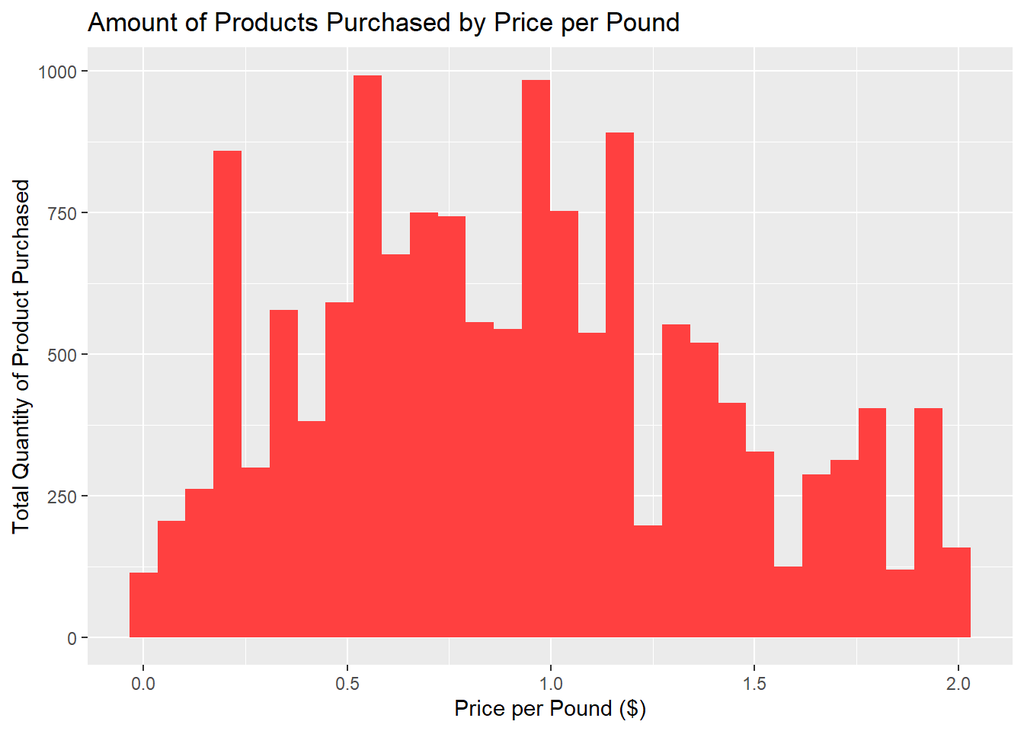

```r
create_unit_histogram(products_lb, lb, 2, color = "brown1") +
  labs(title = "Amount of Products Purchased by Price per Pound",
       x  = "Price per Pound ($)",
       y = "Total Quantity of Product Purchased"
       )
```

Looking at the boxplot and quantile information for the products themselves indicates that half of the products available have a price per pound below $0.97, and it seems to ring true–about half of the purchases are concentrated below that value, but the other half is spread across a wide range, based on our boxplot above.

Let’s see if there’s any trends based on demographics:

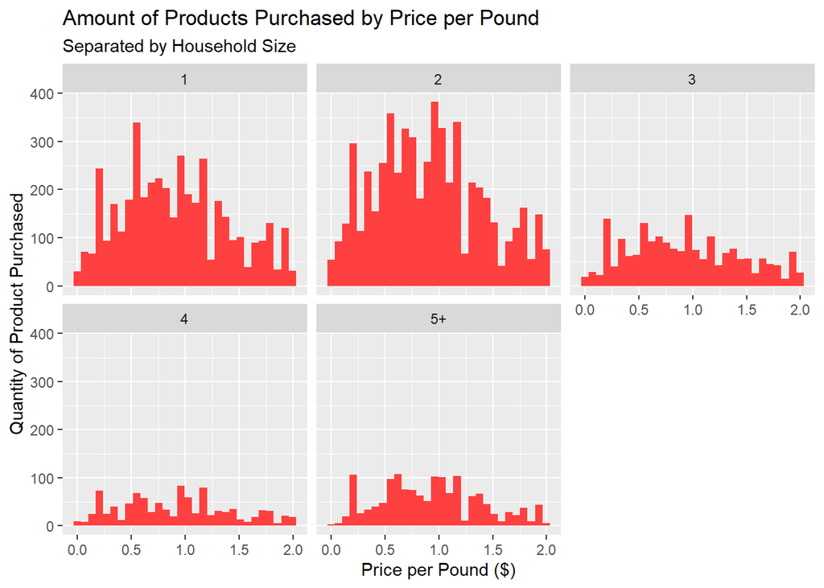

```r
create_unit_histogram(products_lb, lb, 2, color = "brown1") +
    labs(title = "Amount of Products Purchased by Price per Pound",
       subtitle = "Separated by Household Size",
       x  = "Price per Pound ($)",
       y = "Quantity of Product Purchased"
       ) +
    facet_wrap(~ household_size)
```

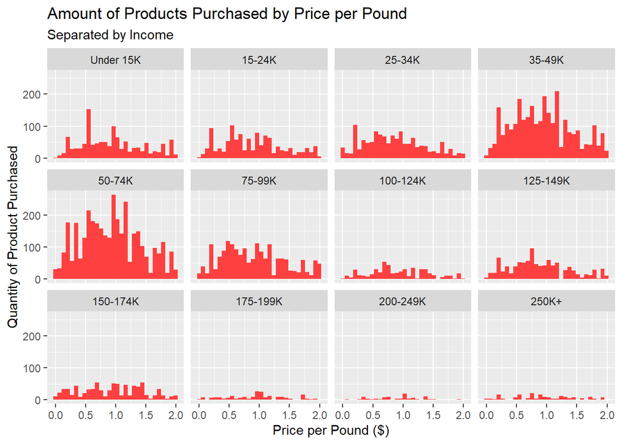

```r
create_unit_histogram(products_lb, lb, 2, color = "brown1") +
    labs(title = "Amount of Products Purchased by Price per Pound",
       subtitle = "Separated by Income",
       x  = "Price per Pound ($)",
       y = "Quantity of Product Purchased"
       ) +
    facet_wrap(~ income)
```

Both of these distributions indicate no clear difference in preference between household sizes or income ranges; the differences in amount likely indicates there are more households in certain household sizes or income ranges over the others. Generally, though, most people prefer those lower prices per pound.

Now let’s look at average sales value based on price per pound.

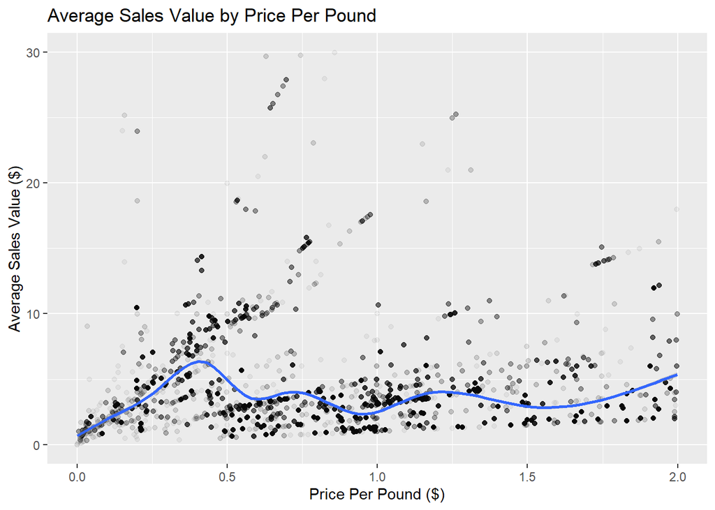

```r
create_avg_sv_scatter(products_lb, 2) +
  labs(title = "Average Sales Value by Price Per Pound",
       x = "Price Per Pound ($)",
       y = "Average Sales Value ($)")
```

The peak below 0.5 is surprising, as it indicates a high general price but low price per pound. These may be bulk products, and we should look for a similar peak in the total sales to see if there’s a lot of sales from these products, as it isn’t entirely clear from the histogram if there are a lot of purchases for this price per count.

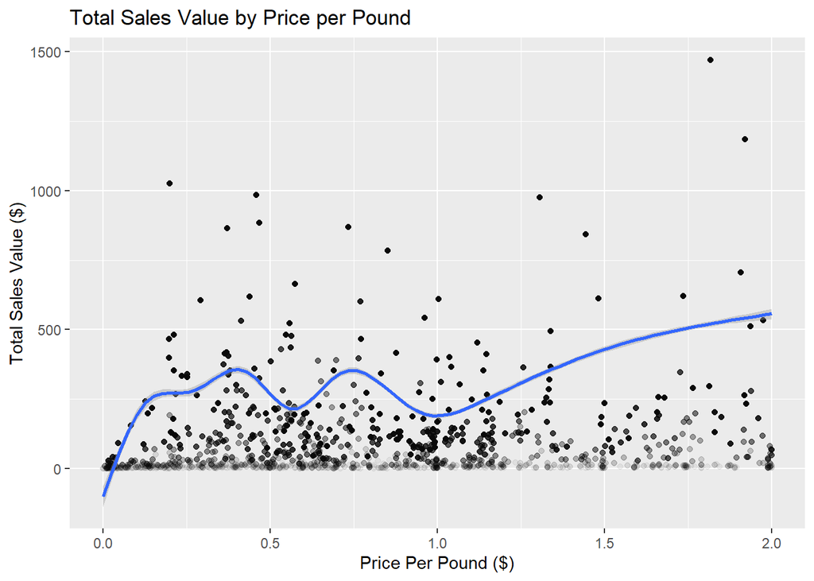

```r
create_total_sv_scatter(products_lb, 2) +
  labs(title = "Total Sales Value by Price per Pound",
       x = "Price Per Pound ($)",
       y = "Total Sales Value ($)")
```

There’s still a peak here at that same price per pound, but it’s not as significant as expected. In addition, the trend’s increase on the right half of the graph, coupled with the high average sales value but somewhat low purchases indicates rising prices that are not mirrored by many purchases. As a result, this indicates a general preference for lower/mid-range prices. Finally, let’s look at the products distribution.

[figure not shown]

```r
create_products_scatter(products_lb, 2) +
  labs(title = "Quantity of Products by Price Per Pound",
       x = "Price Per Pound ($)",
       y = "Quantity of Products")
```

Similarly to the count distribution, the amount of products for each price per pound is similar across the board, which indicates that our trends aren’t heavily affected by the number of products at each price per pound.

### Ounces

#### Overall

Finally, let’s look at ounces.

First, let’s create a histogram for all products measured in ounces:

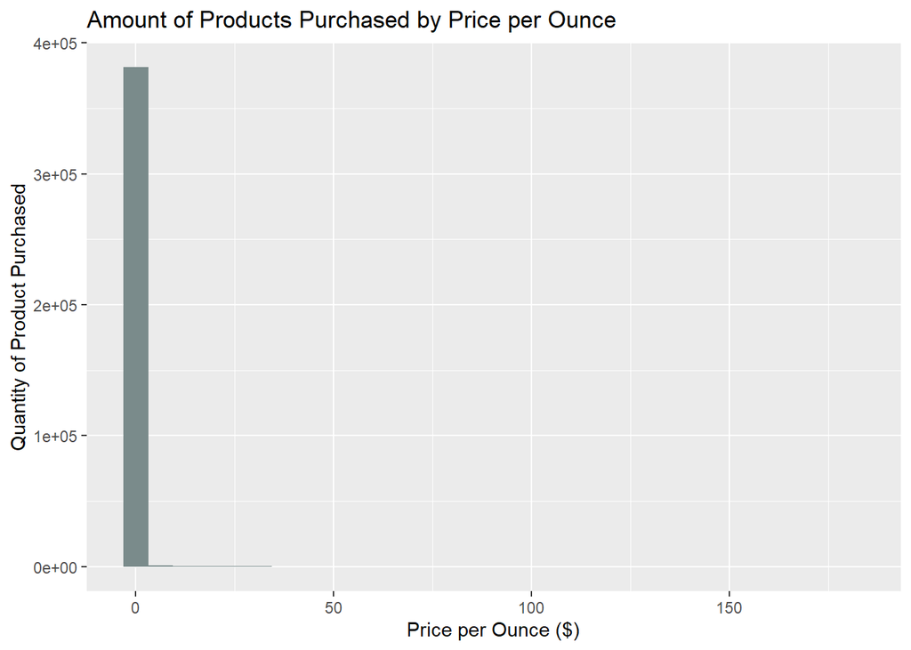

```r
create_unit_histogram(products_oz, oz, color = "lightcyan4") +
    labs(title = "Amount of Products Purchased by Price per Ounce",
       x  = "Price per Ounce ($)",
       y = "Quantity of Product Purchased"
       )
```

This initial distribution is different than the initial distributions for pound and count. Let’s look at the boxplot and quantile information:

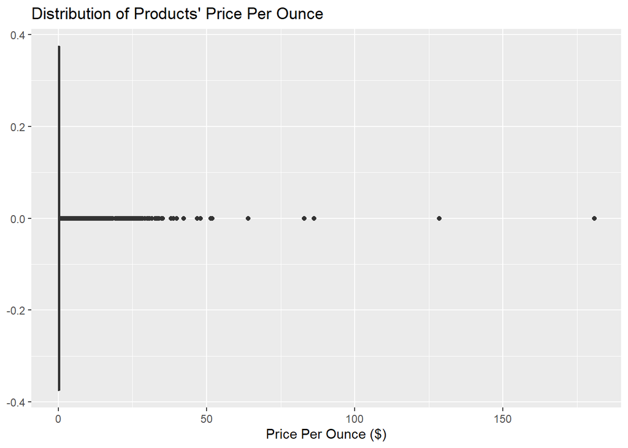

```r
create_unit_boxplot(products_oz, color = "lightcyan4") +
  labs(title = "Distribution of Products' Price Per Ounce",
       x = "Price Per Ounce ($)")
```

Interesting. Clearly, there is very large overall range of prices for products measured in ounces. This is so spread out that it’s hard to even tell what the range between the first and third quantile is–is it significantly close to 0, or does it extend somewhat?

```r
find_unit_quantiles(products_oz)
```

```
## # A tibble: 5 × 1
##   quantile
##      <dbl>
## 1    0
## 2    0.106
## 3    0.192
## 4    0.336
## 5  181.
```

Woah, this is wildly different than the other distributions. Let’s make a new histogram with max price of 0.35.

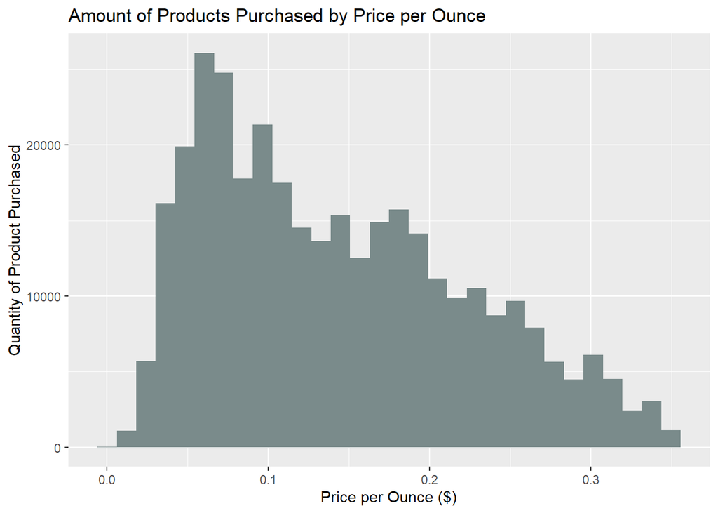

```r
create_unit_histogram(products_oz, oz, 0.35, "lightcyan4") +
  labs(title = "Amount of Products Purchased by Price per Ounce",
       x  = "Price per Ounce ($)",
       y = "Quantity of Product Purchased"
       )
```

Similarly to the count distribution, there’s a clear preference here for lower price-per-ounce products. Let’s see if there’s demographic differences:

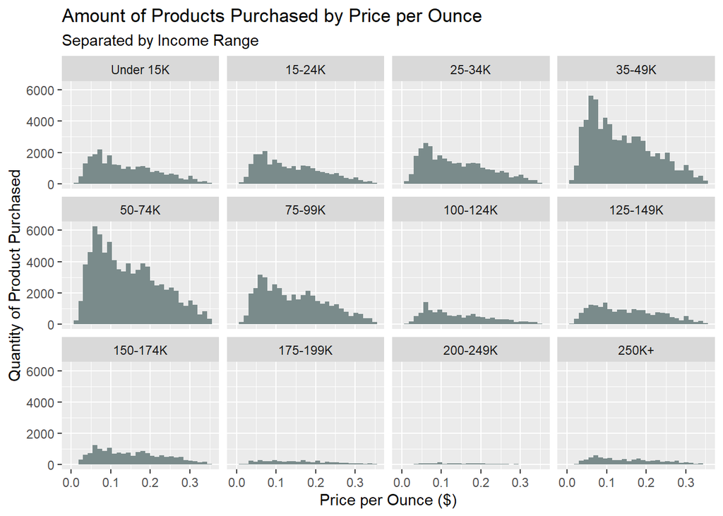

```r
create_unit_histogram(products_oz, oz, 0.35, "lightcyan4") +
  labs(title = "Amount of Products Purchased by Price per Ounce",
       subtitle = "Separated by Income Range",
       x  = "Price per Ounce ($)",
       y = "Quantity of Product Purchased"
       ) +
  facet_wrap(~income)
```

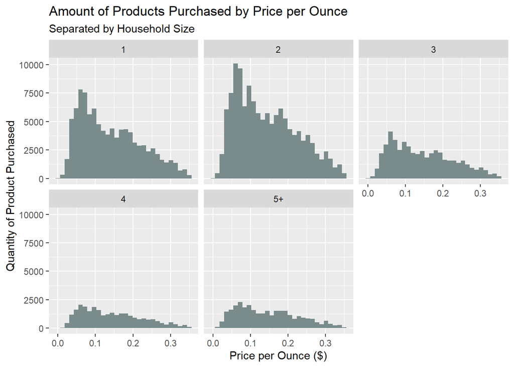

```r
create_unit_histogram(products_oz, oz, 0.35, "lightcyan4") +
  labs(title = "Amount of Products Purchased by Price per Ounce",
       subtitle = "Separated by Household Size",
       x  = "Price per Ounce ($)",
       y = "Quantity of Product Purchased"
       ) +
  facet_wrap(~household_size)
```

Like the others, there’s no clear difference here that couldn’t be explained by a larger number of households in the sections with more purchases. Let’s look at average and total sales values.

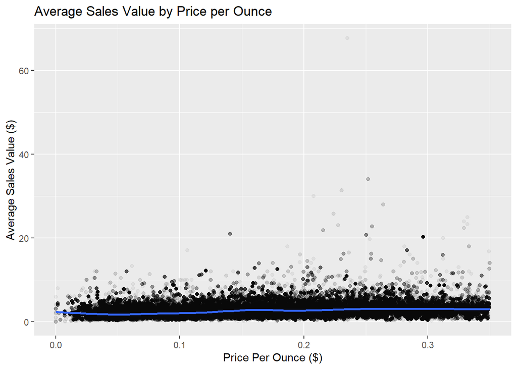

```r
create_avg_sv_scatter(products_oz, 0.35) +
  labs(title = "Average Sales Value by Price per Ounce",
       x = "Price Per Ounce ($)",
       y = "Average Sales Value ($)")
```

Not many conclusions to draw here. Let’s look at total sales.

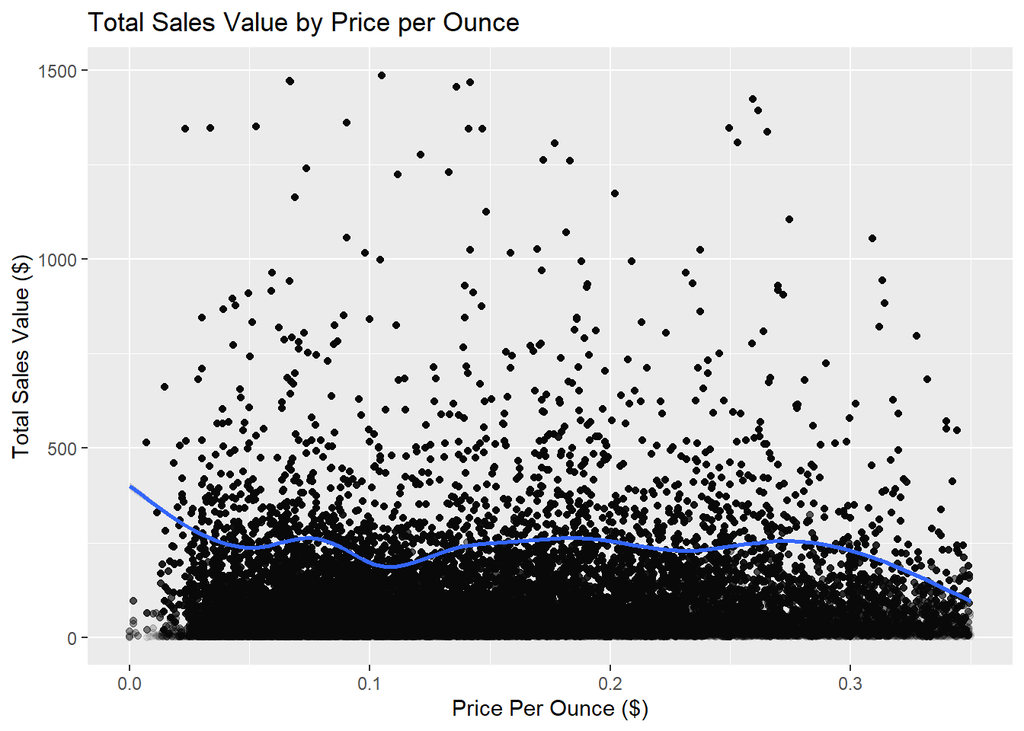

```r
create_total_sv_scatter(products_oz, 0.35) +
  labs(title = "Total Sales Value by Price per Ounce",
       x = "Price Per Ounce ($)",
       y = "Total Sales Value ($)")
```

We could say there’s a slight decrease in total sales as price per ounce increases, but it’s not clear enough to be certain. Let’s examine a couple product categories to see if we can find any trends.

#### Beer

First, we’ll find our quantiles and do a histogram.

```r
find_category_quantiles(products_oz, "BEER")
```

```
## # A tibble: 5 × 1
##   quantile
##      <dbl>
## 1   0.0301
## 2   0.385
## 3   0.566
## 4   0.801
## 5   1.43
```

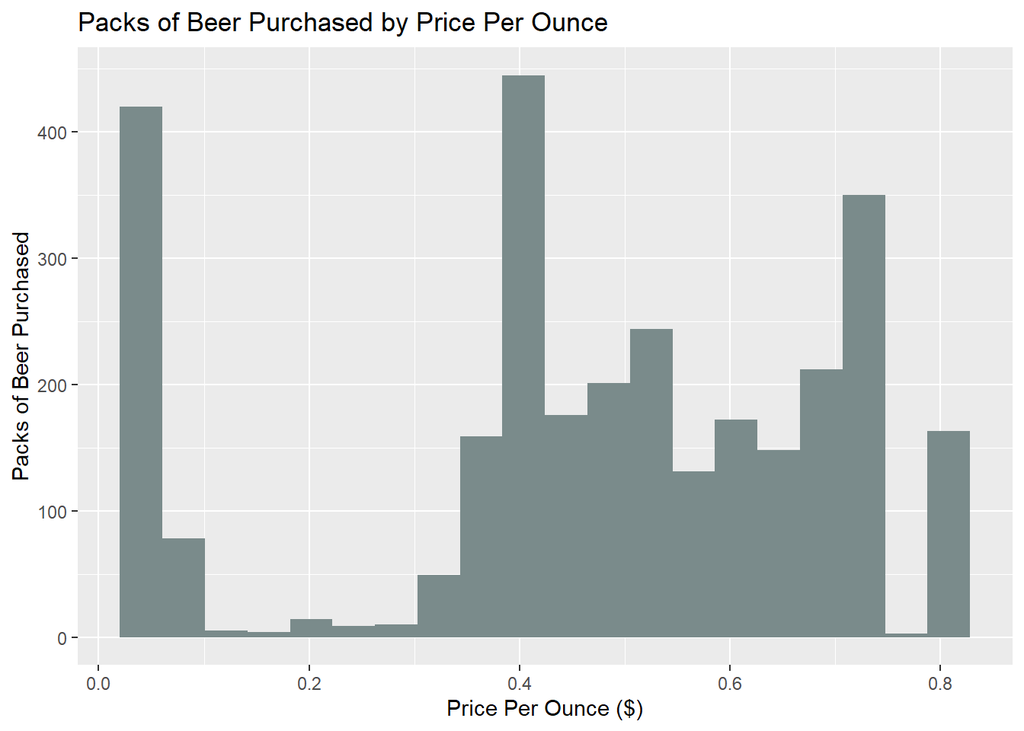

```r
create_category_histogram(products_oz, "BEER", 0.8, color = "lightcyan4") +
  labs(title = "Packs of Beer Purchased by Price Per Ounce",
       x = "Price Per Ounce ($)",
       y = "Packs of Beer Purchased")
```

Now, let’s find average and total sales values.

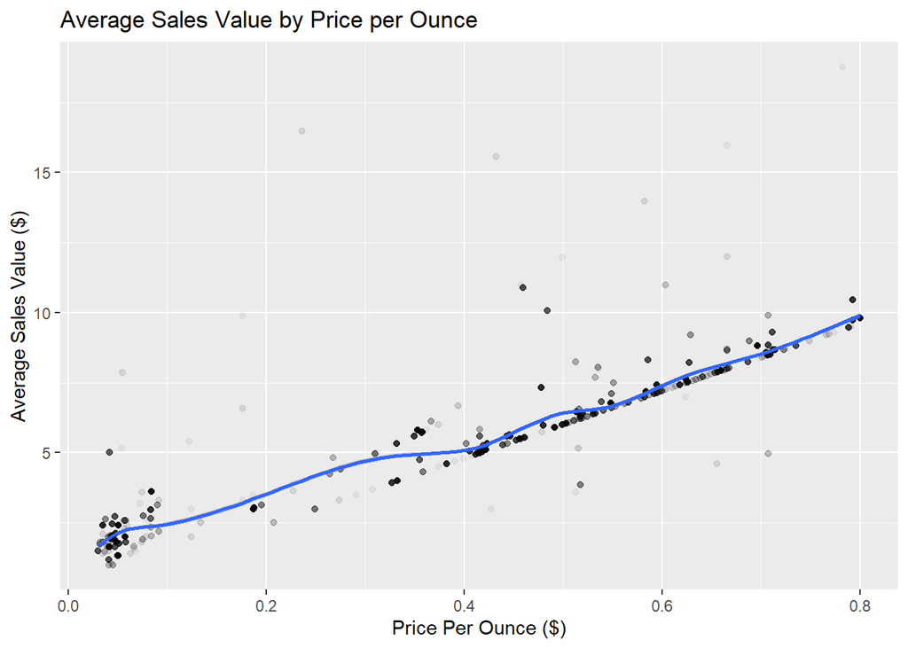

```r
products_oz %>%
  filter(str_detect(product_category, regex("BEER"))) %>%
  inner_join(transactions) %>%
  mutate(price_per_oz = (sales_value / quantity / package_size)) %>%
  group_by(product_id) %>%
  mutate(avg_ppo = mean(price_per_oz)) %>%
  filter(avg_ppo < 0.8) %>%
  group_by(avg_ppo, product_id) %>%
  mutate(avg_sales_value = mean(sales_value)) %>%
  ggplot(aes(x = avg_ppo, y = avg_sales_value)) +
  geom_point(alpha = 0.05) +
  labs(title = "Average Sales Value by Price per Ounce",
       x = "Price Per Ounce ($)",
       y = "Average Sales Value ($)") +
  geom_smooth()
```

There’s a clear increase in average sales value as price per ounce increases, but its almost linear trend indicates it may be because of the increase in price per ounce.

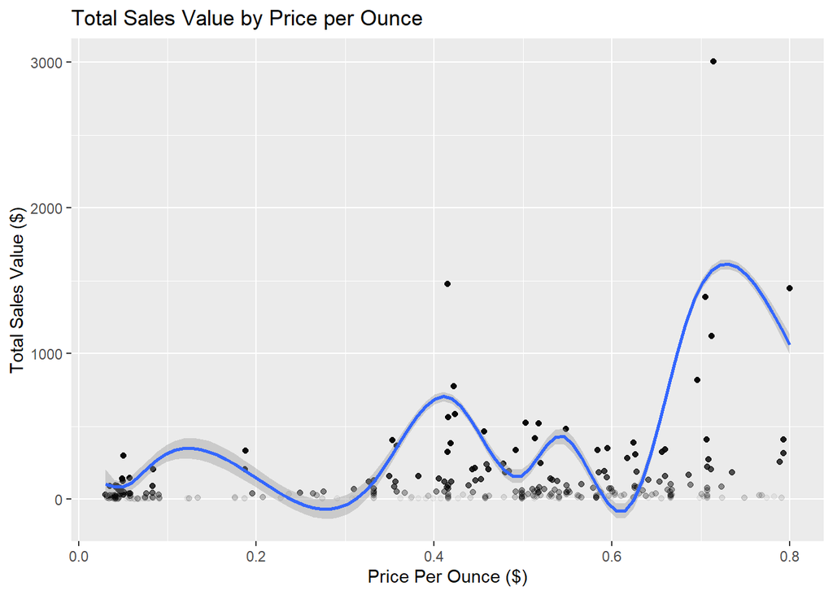

```r
products_oz %>%
  filter(str_detect(product_category, regex("BEER"))) %>%
  inner_join(transactions) %>%
  mutate(price_per_oz = (sales_value / quantity / package_size)) %>%
  group_by(product_id) %>%
  mutate(avg_ppo = mean(price_per_oz)) %>%
  filter(avg_ppo < 0.8) %>%
  group_by(avg_ppo, product_id) %>%
  mutate(total_sales_value = sum(sales_value)) %>%
  ggplot(aes(x = avg_ppo, y = total_sales_value)) +
  geom_point(alpha = 0.05) +
  labs(title = "Total Sales Value by Price per Ounce",
       x = "Price Per Ounce ($)",
       y = "Total Sales Value ($)") +
  geom_smooth()
```

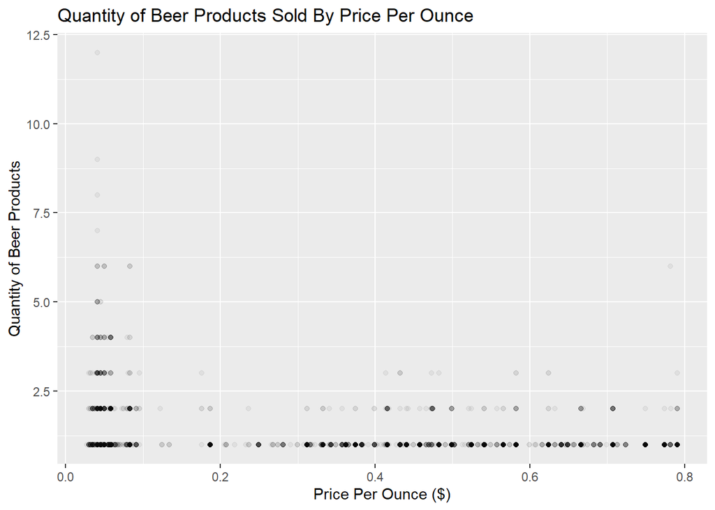

```r
products_oz %>%
  filter(str_detect(product_category, regex("BEER"))) %>%
  inner_join(transactions) %>%
  mutate(price_per_unit = (sales_value / quantity / package_size)) %>%
  filter(price_per_unit <= 0.8) %>%
  ggplot(aes(x = price_per_unit, y = quantity)) +
  geom_point(alpha = 0.05) +
  labs(title = "Quantity of Beer Products Sold By Price Per Ounce",
       x = "Price Per Ounce ($)",
       y = "Quantity of Beer Products")
```

Even though there’s not many beer products sold at a price per ounce of 0.65 and above, a lot of purchases and total sales come from that amount. In conclusion, more expensive beer is enjoyed by buyers just as much as inexpensive/regular beer, but it brings in a lot more sales.

#### Bread

A classic food, bread should give us some great data. First, quantiles and histogram.

```r
find_category_quantiles(products_oz, "BREAD")
```

```
## # A tibble: 5 × 1
##   quantile
##      <dbl>
## 1   0.0156
## 2   0.0723
## 3   0.102
## 4   0.146
## 5   0.586
```

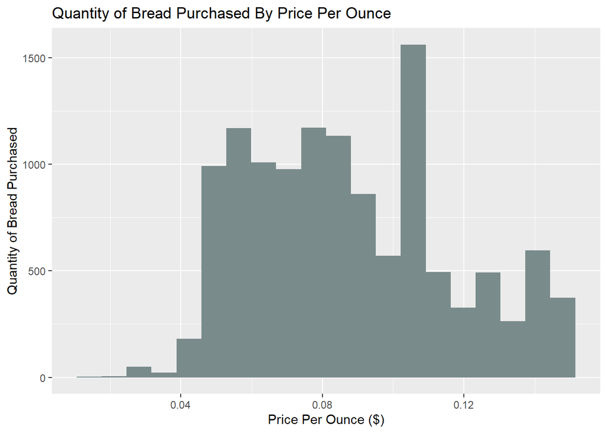

```r
create_category_histogram(products_oz, "BREAD", 0.15, color = "lightcyan4") +
  labs(title = "Quantity of Bread Purchased By Price Per Ounce",
       x = "Price Per Ounce ($)",
       y = "Quantity of Bread Purchased")
```

Interesting. Bread purchases are preferred in the middle range. What about average and total sales?

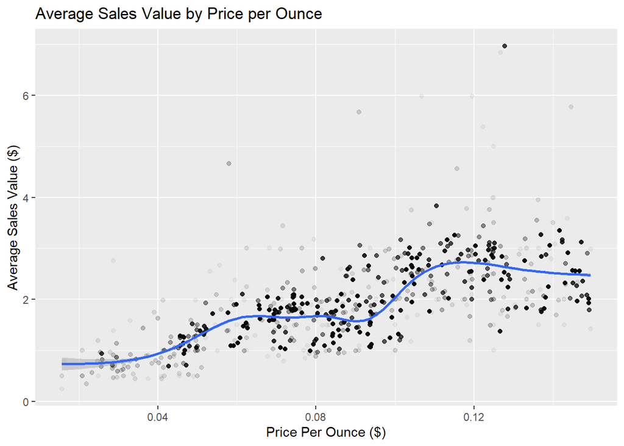

```r
products_oz %>%
  filter(str_detect(product_category, regex("BREAD"))) %>%
  inner_join(transactions) %>%
  mutate(price_per_oz = (sales_value / quantity / package_size)) %>%
  group_by(product_id) %>%
  mutate(avg_ppo = mean(price_per_oz)) %>%
  filter(avg_ppo < 0.15) %>%
  group_by(avg_ppo, product_id) %>%
  mutate(avg_sales_value = mean(sales_value)) %>%
  ggplot(aes(x = avg_ppo, y = avg_sales_value)) +
  geom_point(alpha = 0.05) +
  labs(title = "Average Sales Value by Price per Ounce",
       x = "Price Per Ounce ($)",
       y = "Average Sales Value ($)") +
  geom_smooth()
```

This tells us more information about the bread purchases. In general, higher price per ounce leads to higher overall price for bread. Let’s look at total sales.

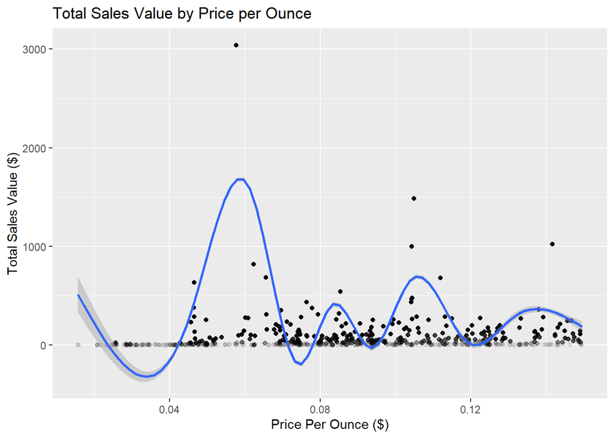

```r
products_oz %>%
  filter(str_detect(product_category, regex("BREAD"))) %>%
  inner_join(transactions) %>%
  mutate(price_per_oz = (sales_value / quantity / package_size)) %>%
  group_by(product_id) %>%
  mutate(avg_ppo = mean(price_per_oz)) %>%
  filter(avg_ppo < 0.15) %>%
  group_by(avg_ppo, product_id) %>%
  mutate(total_sales_value = sum(sales_value)) %>%
  ggplot(aes(x = avg_ppo, y = total_sales_value)) +
  geom_point(alpha = 0.05) +
  labs(title = "Total Sales Value by Price per Ounce",
       x = "Price Per Ounce ($)",
       y = "Total Sales Value ($)") +
  geom_smooth()
```

Well, a couple of bread products are really popular! Let’s filter this a bit to get a better trend idea.

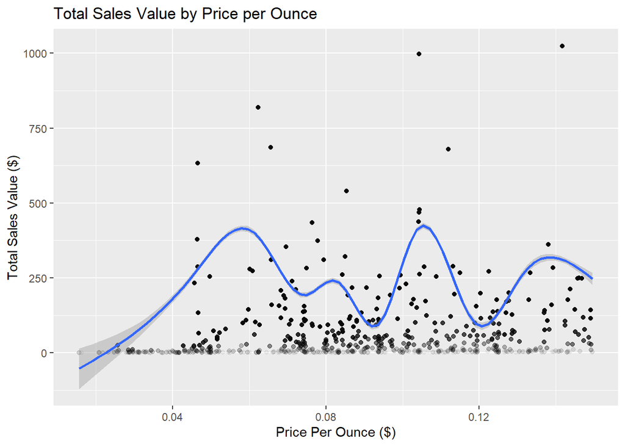

```r
products_oz %>%
  filter(str_detect(product_category, regex("BREAD"))) %>%
  inner_join(transactions) %>%
  mutate(price_per_oz = (sales_value / quantity / package_size)) %>%
  group_by(product_id) %>%
  mutate(avg_ppo = mean(price_per_oz)) %>%
  filter(avg_ppo < 0.15) %>%
  group_by(avg_ppo, product_id) %>%
  mutate(total_sales_value = sum(sales_value)) %>%
  filter(total_sales_value < 1450) %>%
  ggplot(aes(x = avg_ppo, y = total_sales_value)) +
  geom_point(alpha = 0.05) +
  labs(title = "Total Sales Value by Price per Ounce",
       x = "Price Per Ounce ($)",
       y = "Total Sales Value ($)") +
  geom_smooth()
```

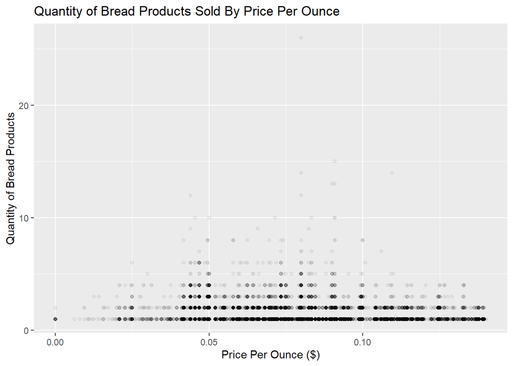

```r
products_oz %>%
  filter(str_detect(product_category, regex("BREAD"))) %>%
  inner_join(transactions) %>%
  mutate(price_per_unit = (sales_value / quantity / package_size)) %>%
  filter(price_per_unit <= 0.14) %>%
  ggplot(aes(x = price_per_unit, y = quantity)) +
  geom_point(alpha = 0.05) +
  labs(title = "Quantity of Bread Products Sold By Price Per Ounce",
       x = "Price Per Ounce ($)",
       y = "Quantity of Bread Products")
```

Looking at this, a bit of those peaks could be explained by the extra number of products at those prices, but generally those peaks were significant enough to warrant acknowledgement.

Overall, 0.06 and 0.10 dollars per ounce are the perfect prices for bread purchases. Increasing the availability of bread at these prices could be very effective.

## Conclusion/Summary

When considering growth opportunities for Regork, we wanted to analyze how product pricing affects customers’ purchasing behavior. We analyzed this by using products, transactions, and demographics data from the Complete Journey data set, and we looked at overall purchases, average sales values, and total sales values based on price per unit. With this, we found a narrative that was sometimes clear (as in the case of products measured by count) and other times not necessarily meaningful (as in the case of products measured by ounces overall). Interestingly, there did not appear to be significant differences in preferences based on demographics.

Overall, we propose a focus on increasing availability of low price per count and price per ounce products as well as mid-range price per pound products. We also suggest more in-depth, category-based analysis, especially for products measured in ounces, in order to get a more complete analysis.

There are some limitations to this analysis. Most notably, perhaps, is the expectation that there are products within the same measurement categories with wildly different expected prices. We tried to combat this by taking the average price per unit by product in order to not have one heavily-purchased product skew the data as well as only taking the first three quartiles of data when creating our new distributions. With more time or more data mining power, though, each product category could/should be considered individually to get more accurate data. This is especially important for products measured in ounces, as there are over 40,000 products in that category.